# Project 7: House Price Analysis

Seif Kungulio

2025-02-24

## **Data Loading**

Structure of the dataset

```
## 'data.frame':    21613 obs. of  21 variables:
##  $ id           : num  7.13e+09 6.41e+09 5.63e+09 2.49e+09 1.95e+09 ...
##  $ date         : chr  "20141013T000000" "20141209T000000" "20150225T000000" "20141209T000000" ...
##  $ price        : num  221900 538000 180000 604000 510000 ...
##  $ bedrooms     : int  3 3 2 4 3 4 3 3 3 3 ...
##  $ bathrooms    : num  1 2.25 1 3 2 4.5 2.25 1.5 1 2.5 ...
##  $ sqft_living  : int  1180 2570 770 1960 1680 5420 1715 1060 1780 1890 ...
##  $ sqft_lot     : int  5650 7242 10000 5000 8080 101930 6819 9711 7470 6560 ...
##  $ floors       : num  1 2 1 1 1 1 2 1 1 2 ...
##  $ waterfront   : int  0 0 0 0 0 0 0 0 0 0 ...
##  $ view         : int  0 0 0 0 0 0 0 0 0 0 ...
##  $ condition    : int  3 3 3 5 3 3 3 3 3 3 ...
##  $ grade        : int  7 7 6 7 8 11 7 7 7 7 ...
##  $ sqft_above   : int  1180 2170 770 1050 1680 3890 1715 1060 1050 1890 ...
##  $ sqft_basement: int  0 400 0 910 0 1530 0 0 730 0 ...
##  $ yr_built     : int  1955 1951 1933 1965 1987 2001 1995 1963 1960 2003 ...
##  $ yr_renovated : int  0 1991 0 0 0 0 0 0 0 0 ...
##  $ zipcode      : int  98178 98125 98028 98136 98074 98053 98003 98198 98146 98038 ...
##  $ lat          : num  47.5 47.7 47.7 47.5 47.6 ...
##  $ long         : num  -122 -122 -122 -122 -122 ...
##  $ sqft_living15: int  1340 1690 2720 1360 1800 4760 2238 1650 1780 2390 ...
##  $ sqft_lot15   : int  5650 7639 8062 5000 7503 101930 6819 9711 8113 7570 ...
```

Statistical summary of the dataset

```
##        id                date               price            bedrooms
##  Min.   :1.000e+06   Length:21613       Min.   :  75000   Min.   : 0.000
##  1st Qu.:2.123e+09   Class :character   1st Qu.: 321950   1st Qu.: 3.000
##  Median :3.905e+09   Mode  :character   Median : 450000   Median : 3.000
##  Mean   :4.580e+09                      Mean   : 540182   Mean   : 3.371
##  3rd Qu.:7.309e+09                      3rd Qu.: 645000   3rd Qu.: 4.000
##  Max.   :9.900e+09                      Max.   :7700000   Max.   :33.000
##    bathrooms      sqft_living       sqft_lot           floors
##  Min.   :0.000   Min.   :  290   Min.   :    520   Min.   :1.000
##  1st Qu.:1.750   1st Qu.: 1427   1st Qu.:   5040   1st Qu.:1.000
##  Median :2.250   Median : 1910   Median :   7618   Median :1.500
##  Mean   :2.115   Mean   : 2080   Mean   :  15107   Mean   :1.494
##  3rd Qu.:2.500   3rd Qu.: 2550   3rd Qu.:  10688   3rd Qu.:2.000
##  Max.   :8.000   Max.   :13540   Max.   :1651359   Max.   :3.500
##    waterfront            view          condition         grade
##  Min.   :0.000000   Min.   :0.0000   Min.   :1.000   Min.   : 1.000
##  1st Qu.:0.000000   1st Qu.:0.0000   1st Qu.:3.000   1st Qu.: 7.000
##  Median :0.000000   Median :0.0000   Median :3.000   Median : 7.000
##  Mean   :0.007542   Mean   :0.2343   Mean   :3.409   Mean   : 7.657
##  3rd Qu.:0.000000   3rd Qu.:0.0000   3rd Qu.:4.000   3rd Qu.: 8.000
##  Max.   :1.000000   Max.   :4.0000   Max.   :5.000   Max.   :13.000
##    sqft_above   sqft_basement       yr_built     yr_renovated
##  Min.   : 290   Min.   :   0.0   Min.   :1900   Min.   :   0.0
##  1st Qu.:1190   1st Qu.:   0.0   1st Qu.:1951   1st Qu.:   0.0
##  Median :1560   Median :   0.0   Median :1975   Median :   0.0
##  Mean   :1788   Mean   : 291.5   Mean   :1971   Mean   :  84.4
##  3rd Qu.:2210   3rd Qu.: 560.0   3rd Qu.:1997   3rd Qu.:   0.0
##  Max.   :9410   Max.   :4820.0   Max.   :2015   Max.   :2015.0
##     zipcode           lat             long        sqft_living15
##  Min.   :98001   Min.   :47.16   Min.   :-122.5   Min.   : 399
##  1st Qu.:98033   1st Qu.:47.47   1st Qu.:-122.3   1st Qu.:1490
##  Median :98065   Median :47.57   Median :-122.2   Median :1840
##  Mean   :98078   Mean   :47.56   Mean   :-122.2   Mean   :1987
##  3rd Qu.:98118   3rd Qu.:47.68   3rd Qu.:-122.1   3rd Qu.:2360
##  Max.   :98199   Max.   :47.78   Max.   :-121.3   Max.   :6210
##    sqft_lot15
##  Min.   :   651
##  1st Qu.:  5100
##  Median :  7620
##  Mean   : 12768
##  3rd Qu.: 10083
##  Max.   :871200
```

## **2. Graphical Summary**

### a) Histogram of Prices

Histogram to show the distribution of house prices.

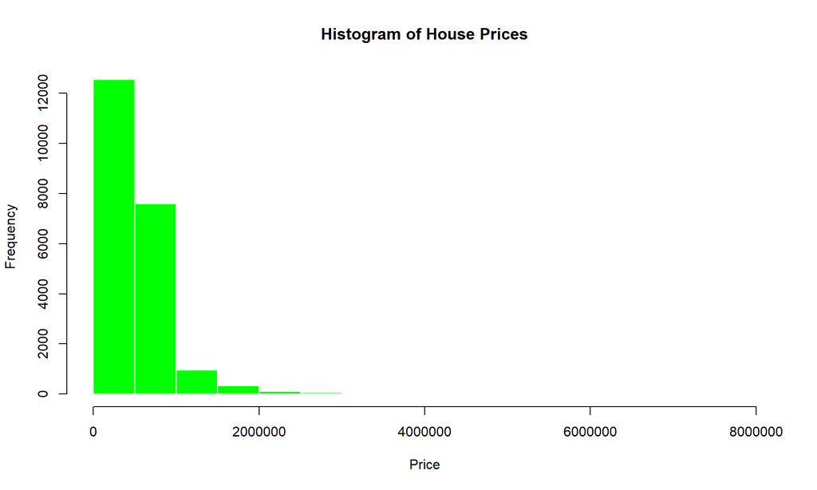

### b) Box Plot of Prices Against View

Create a box plot to compare the distribution of prices by the view variable.

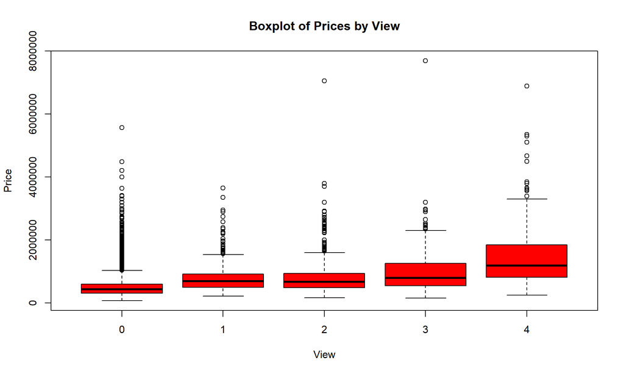

### c) Scatter Plot of Prices Against Sqft Living

Generate a scatter plot to explore the relationship between price and sqft_living.

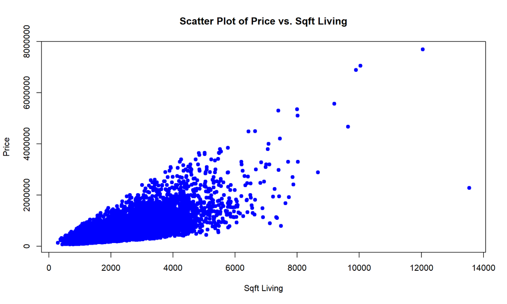

## **3. Linear Models for Forecasting Price**

Now, I will build three different linear models.

### a) Model 1:

Forecast price using Bedrooms, Bathrooms, and Sqft Living

```
##
## Call:
## lm(formula = price ~ bedrooms + bathrooms + sqft_living, data = kc_house_data)
##
## Residuals:
##      Min       1Q   Median       3Q      Max
## -1644794  -144361   -22891   102420  4178611
##
## Coefficients:
##               Estimate Std. Error t value            Pr(>|t|)
## (Intercept)  74662.099   6917.977  10.792 <0.0000000000000002 ***
## bedrooms    -57906.631   2336.062 -24.788 <0.0000000000000002 ***
## bathrooms     7928.708   3512.744   2.257               0.024 *
## sqft_living    309.605      3.089 100.238 <0.0000000000000002 ***
## ---
## Signif. codes:  0 '***' 0.001 '**' 0.01 '*' 0.05 '.' 0.1 ' ' 1
##
## Residual standard error: 258000 on 21609 degrees of freedom
## Multiple R-squared:  0.5069, Adjusted R-squared:  0.5069
## F-statistic:  7406 on 3 and 21609 DF,  p-value: < 0.00000000000000022
```

Adjusted R-Squared for Model 1 is **0.5068679**

### b) Model 2:

Forecast price including all cross-effects between Bedrooms, Bathrooms, and Sqft Living

The model includes all interaction terms among these three variables.

```
##
## Call:
## lm(formula = price ~ bedrooms * bathrooms * sqft_living, data = kc_house_data)
##
## Residuals:
##      Min       1Q   Median       3Q      Max
## -3763654  -136129   -28111    95553  3367308
##
## Coefficients:
##                                    Estimate   Std. Error t value
## (Intercept)                     433859.5682   24216.2774  17.916
## bedrooms                        -46698.9049    7338.1346  -6.364
## bathrooms                      -120340.0904   13819.9920  -8.708
## sqft_living                        -24.9019      15.9689  -1.559
## bedrooms:bathrooms               -4824.7473    3569.5223  -1.352
## bedrooms:sqft_living                32.2734       3.8987   8.278
## bathrooms:sqft_living              112.1083       5.0137  22.360
## bedrooms:bathrooms:sqft_living     -10.1494       0.9673 -10.493
##                                            Pr(>|t|)
## (Intercept)                    < 0.0000000000000002 ***
## bedrooms                             0.000000000201 ***
## bathrooms                      < 0.0000000000000002 ***
## sqft_living                                   0.119
## bedrooms:bathrooms                            0.177
## bedrooms:sqft_living           < 0.0000000000000002 ***
## bathrooms:sqft_living          < 0.0000000000000002 ***
## bedrooms:bathrooms:sqft_living < 0.0000000000000002 ***
## ---
## Signif. codes:  0 '***' 0.001 '**' 0.01 '*' 0.05 '.' 0.1 ' ' 1
##
## Residual standard error: 248200 on 21605 degrees of freedom
## Multiple R-squared:  0.5436, Adjusted R-squared:  0.5435
## F-statistic:  3677 on 7 and 21605 DF,  p-value: < 0.00000000000000022
```

Adjusted R-Squared for Model 2 is **0.5434959**

### c) Model 3:

Forecast price using Bedrooms, Bathrooms, Sqft Living, Waterfront, and Grade

```
##
## Call:
## lm(formula = price ~ bedrooms + bathrooms + sqft_living + waterfront +
##     grade, data = kc_house_data)
##
## Residuals:
##      Min       1Q   Median       3Q      Max
## -1263684  -130226   -20778    98943  4755524
##
## Coefficients:
##                Estimate  Std. Error t value             Pr(>|t|)
## (Intercept) -488328.010   14325.852  -34.09 < 0.0000000000000002 ***
## bedrooms     -31983.762    2210.015  -14.47 < 0.0000000000000002 ***
## bathrooms    -25540.177    3347.126   -7.63   0.0000000000000244 ***
## sqft_living     213.446       3.455   61.78 < 0.0000000000000002 ***
## waterfront1  799119.429   18927.669   42.22 < 0.0000000000000002 ***
## grade         96692.175    2226.941   43.42 < 0.0000000000000002 ***
## ---
## Signif. codes:  0 '***' 0.001 '**' 0.01 '*' 0.05 '.' 0.1 ' ' 1
##
## Residual standard error: 238600 on 21607 degrees of freedom
## Multiple R-squared:  0.5782, Adjusted R-squared:  0.5781
## F-statistic:  5923 on 5 and 21607 DF,  p-value: < 0.00000000000000022
```

Adjusted R-Squared for Model 3 is **0.578082**

### Model Comparison and Recommendation

Compare the models using adjusted R-squared metrics. The model with a higher adjusted R-squared is generally preferred.

- Adjusted R-Squared for Model 1 is **0.5068679**
- Adjusted R-Squared for Model 2 is **0.5434959**
- Adjusted R-Squared for Model 3 is **0.578082**

```
## The best model is Model 3 with Adjusted R-Squared of 0.578082
```